# Nerve-root compression on MRI in primary-care patients with sciatica

Dataset 3: Sciatica in primary care

RSR feasibility analysis

2026-08-03

# Introduction

The clinical question behind this dataset is a diagnostic one: when a GP sees a patient with leg pain and finds the classical signs of sciatica, how well do those signs predict what the scan will actually show? These data come from a cross-sectional study of 395 adults presenting to Dutch general practices with a new episode of sciatica, all of whom had a standardised history, a physical examination and a lumbar MRI regardless of the clinician’s suspicion (Verwoerd et al.; sciatica in general practice, MRI substudy). Because the MRI was done in everyone, the usual verification bias that plagues diagnostic studies is absent, and the signs can be assessed against the imaging finding they are supposed to detect.

This is a *Purpose 3* analysis: several predictors are of interest and the question is which remain associated with the outcome after mutual adjustment.

# Methods

**Data source.** Cross-sectional data from a primary-care sciatica cohort: 395 adults consulting Dutch general practitioners with a new episode of sciatica, each assessed at a single occasion with a structured history, a physical examination and a lumbar MRI. Age ranged from 19 to 82 years.

**Variables.** The outcome is `mri_nerve_root_compression`, coded 1 when nerve-root compression is present on MRI; **the modelled event is presence of compression**, which occurs in 230 of 393 analysed patients (58.5%). Predictors are `age_yrs` (years), `sex` (reference: female, the larger group), `bmi` (kg/m²), `leg_pain_worse` (patient reports leg pain worse than back pain; reference: no), `cough_sneeze_positive` (coughing or sneezing reproduces the leg pain; reference: no), `subjective_sensory_changes` (reference: no), `below_knee_pain` (pain radiates below the knee; reference: no), `neural_tension_positive` (at least one positive neural-tension test; reference: no) and `neurological_deficit` (at least one deficit on examination; reference: no). Every binary predictor takes “no / sign absent” as its reference so that odds ratios above 1 mean the sign is associated with compression.

**`clinician_sciatica` is deliberately excluded from the main model.** It is the GP’s own high-confidence diagnosis of sciatica – not an independent observation, but a summary judgement formed from the very signs listed above. In this file it correlates r = 0.61 with `neural_tension_positive`, r = 0.54 with `below_knee_pain` and r = 0.49 with `neurological_deficit`. Entering it alongside those signs would ask each sign to explain variation in the outcome that its own summary has already absorbed; the coefficients would become answers to a question nobody asked. A sensitivity model containing it, with the resulting variance inflation factors, is reported in the Diagnostics section rather than being used for inference. `id` is a row label and is excluded from every model.

**Statistical analysis.** Logistic regression (`glm(family = binomial)`), justified because the outcome is binary. We fitted a univariable model for each predictor first, then a single multivariable model containing all of them. Predictors were chosen in advance on subject-matter grounds, not by significance. Estimates are reported as odds ratios with 95% confidence intervals; significance threshold 0.05. Model fit is summarised with AIC, Tjur’s R² and the number of events per estimated parameter. Assumptions were checked with `performance::check_model()`, focusing on binned residuals, collinearity and influential observations. Analysis used R version 4.6.0 (2026-04-24) with tidyverse, gtsummary and performance.

**Missing data.** Complete-case analysis: 393 of 395 rows were analysed (2 dropped, 0.5%). Missingness in this file is small but real and confined to leg_pain_duration (19), bmi (2), back_pain_duration (2). The outcome and all six clinical signs are complete; the only loss here is from `bmi`. Had `leg_pain_duration` been included the analysed sample would have fallen to 374.

# Results

## Sample characteristics

**Table 1. Sample characteristics by MRI nerve-root compression status.**

| **Characteristic** | **N** | **Overall** N = 393<sup>1</sup> | **No** N = 163<sup>1</sup> | **Yes** N = 230<sup>1</sup> |
| --- | --- | --- | --- | --- |
| age_yrs | 393 | 50 (40, 60) | 48 (37, 60) | 51 (43, 60) |
| sex | 393 |  |  |  |
| Female |  | 236 (60%) | 124 (76%) | 112 (49%) |
| Male |  | 157 (40%) | 39 (24%) | 118 (51%) |
| bmi | 393 | 28.4 (25.5, 32.8) | 28.1 (25.3, 32.5) | 28.7 (25.7, 32.9) |
| leg_pain_worse | 393 | 197 (50%) | 51 (31%) | 146 (63%) |
| cough_sneeze_positive | 393 | 102 (26%) | 20 (12%) | 82 (36%) |
| subjective_sensory_changes | 393 | 243 (62%) | 92 (56%) | 151 (66%) |
| below_knee_pain | 393 | 278 (71%) | 97 (60%) | 181 (79%) |
| neural_tension_positive | 393 | 239 (61%) | 81 (50%) | 158 (69%) |
| neurological_deficit | 393 | 227 (58%) | 71 (44%) | 156 (68%) |

<sup>1</sup> Median (Q1, Q3); n (%)

Compression is present in 58.5% of the analysed sample, so neither class is rare: the smaller class contains 163 patients. The most striking contrast in Table 1 is not a clinical sign at all but sex – 75% of men have compression versus 47% of women. The clinical signs differ far less between the two MRI groups than one would expect: for example 79% of patients with compression report pain below the knee, compared with 60% of those without.

## Exploratory figure

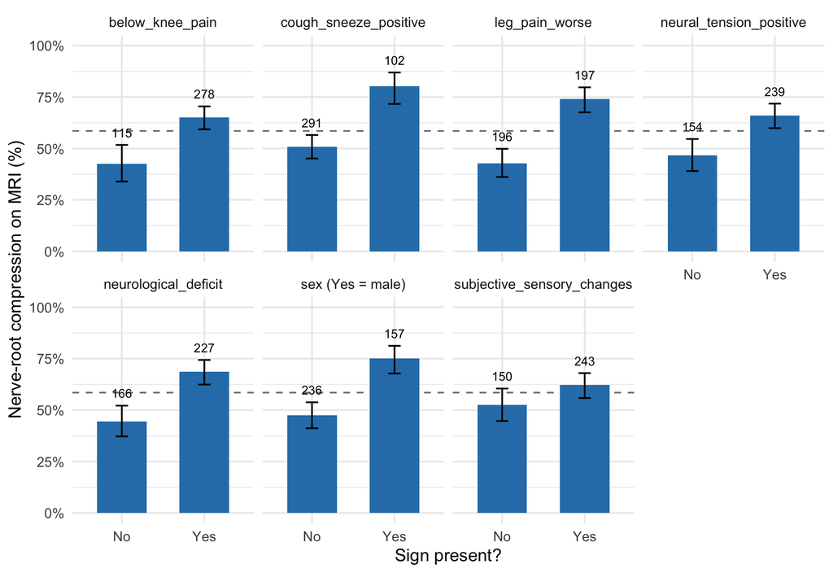

Figure 1. Proportion of patients with nerve-root compression on MRI, by each clinical sign and by sex. Bars are proportions with 95% Wilson confidence intervals; the dashed line is the overall prevalence of compression. Numbers above the bars are group sizes.

## Univariable models

| **Characteristic** | **N** | **OR** | **95% CI** | **p-value** |
| --- | --- | --- | --- | --- |
| age_yrs | 393 | 1.02 | 1.00, 1.03 | 0.031 |
| sex | 393 |  |  |  |
| Female |  | — | — |  |
| Male |  | 3.35 | 2.17, 5.26 | <0.001 |
| bmi | 393 | 1.00 | 0.97, 1.04 | 0.9 |
| leg_pain_worse | 393 |  |  |  |
| No |  | — | — |  |
| Yes |  | 3.82 | 2.50, 5.88 | <0.001 |
| cough_sneeze_positive | 393 |  |  |  |
| No |  | — | — |  |
| Yes |  | 3.96 | 2.35, 6.95 | <0.001 |
| subjective_sensory_changes | 393 |  |  |  |
| No |  | — | — |  |
| Yes |  | 1.48 | 0.98, 2.23 | 0.065 |
| below_knee_pain | 393 |  |  |  |
| No |  | — | — |  |
| Yes |  | 2.51 | 1.62, 3.93 | <0.001 |
| neural_tension_positive | 393 |  |  |  |
| No |  | — | — |  |
| Yes |  | 2.22 | 1.47, 3.37 | <0.001 |
| neurological_deficit | 393 |  |  |  |
| No |  | — | — |  |
| Yes |  | 2.73 | 1.81, 4.15 | <0.001 |

Abbreviations: CI = Confidence Interval, OR = Odds Ratio

The signs predict the clinician, not the scan

Point-biserial correlations, full file (n = 395)

| Clinical sign | r with MRI compression | r with clinician diagnosis |
| --- | --- | --- |
| leg_pain_worse | 0.31 | 0.41 |
| cough_sneeze_positive | 0.26 | 0.25 |
| subjective_sensory_changes | 0.09 | 0.29 |
| below_knee_pain | 0.21 | 0.54 |
| neural_tension_positive | 0.20 | 0.61 |
| neurological_deficit | 0.25 | 0.49 |

The table above is worth pausing on, because it is the most interesting thing in this dataset. Each of the six signs correlates only weakly with the MRI finding (r between 0.09 and 0.31), yet the same signs correlate strongly with the clinician’s diagnosis of sciatica (up to r = 0.61). Fitting the same six signs to the two different outcomes makes the size of the gap explicit: they explain Tjur’s R² = 0.65 of the clinician’s judgement but only R² = 0.16 of the MRI finding. The examination is highly reproducible *as a description of what the clinician concludes* and only weakly informative *about what the scan shows*. That gap is the finding, and it is a better research question than any single coefficient in the model below.

## Why adjustment is needed

The crude odds ratios cannot be read as independent contributions because the signs cluster within patients and because both the signs and the outcome vary with basic demographics. `sex` is the clearest confounder: men are more likely to have compression on MRI (75% versus 47%) and they also present differently – for example 58% of men report leg pain worse than back pain versus 45% of women – so an unadjusted sign estimate partly measures the sex mix of the patients who have that sign. `below_knee_pain` is a second confounder, this time of the examination findings: it correlates r = 0.33 with `neural_tension_positive` and r = 0.36 with `neurological_deficit`, and it is itself associated with compression, so patients with a positive neural-tension test are simply more likely to be patients whose pain radiates below the knee. `age_yrs` is a third: older patients are more likely to show degenerative nerve-root compression (r = 0.11) and less likely to report cough-provoked pain (r = -0.1), so age pushes the crude cough-sneeze estimate around. Mutual adjustment is what lets us ask whether any single sign carries information about the scan that the other signs and the patient’s demographics do not already provide.

## Multivariable model

| **Characteristic** | **OR** | **95% CI** | **p-value** |
| --- | --- | --- | --- |
| age_yrs | 1.01 | 1.00, 1.03 | 0.11 |
| sex |  |  |  |
| Female | — | — |  |
| Male | 3.07 | 1.90, 5.03 | <0.001 |
| bmi | 1.01 | 0.97, 1.05 | 0.6 |
| leg_pain_worse |  |  |  |
| No | — | — |  |
| Yes | 2.38 | 1.42, 4.02 | 0.001 |
| cough_sneeze_positive |  |  |  |
| No | — | — |  |
| Yes | 2.85 | 1.57, 5.34 | <0.001 |
| subjective_sensory_changes |  |  |  |
| No | — | — |  |
| Yes | 1.07 | 0.65, 1.76 | 0.8 |
| below_knee_pain |  |  |  |
| No | — | — |  |
| Yes | 1.27 | 0.73, 2.20 | 0.4 |
| neural_tension_positive |  |  |  |
| No | — | — |  |
| Yes | 1.02 | 0.60, 1.75 | >0.9 |
| neurological_deficit |  |  |  |
| No | — | — |  |
| Yes | 1.97 | 1.20, 3.26 | 0.007 |

Abbreviations: CI = Confidence Interval, OR = Odds Ratio

Model fit

| Statistic | Value |
| --- | --- |
| AIC | 459.300 |
| Null deviance | 533.300 |
| Residual deviance | 439.300 |
| Tjur's R-squared | 0.221 |
| N (complete cases) | 393.000 |
| Events (compression present) | 230.000 |
| Non-events | 163.000 |
| Rarer class | 163.000 |
| Estimated parameters | 10.000 |
| Events per parameter (rarer class) | 16.300 |

Adjusting for all nine predictors, four remain independently associated with nerve-root compression. Sex is by far the strongest: conditional on age, BMI and all six clinical signs, men have 3.07 times the odds of compression (95% CI 1.9 to 5.03, p < 0.001). Pain reproduced by coughing or sneezing carries an odds ratio of 2.85 (95% CI 1.57 to 5.34, p < 0.001), leg pain worse than back pain 2.38 (p = 0.001) and a neurological deficit 1.97 (p = 0.007). The two signs that a clinician would probably weight most heavily contribute nothing once the others are held constant: `neural_tension_positive` has an adjusted odds ratio of 1.02 (95% CI 0.6 to 1.75, p = 0.931) – an odds ratio of essentially exactly 1 – and `subjective_sensory_changes` 1.07 (p = 0.798). `below_knee_pain`, `age_yrs` and `bmi` are also not independently associated.

Fit is modest. AIC is 459.3 against a null deviance of 533.3 and residual deviance 439.3, Tjur’s R² is 0.221, and the area under the ROC curve is 0.775 – better than chance but nowhere near a usable diagnostic rule. Sample size is not the constraint: with 163 patients in the rarer class and 10 estimated parameters there are 16.3 events per parameter, comfortably above the conventional minimum of 10, so the wide confidence intervals on the null signs reflect genuinely weak associations rather than an underpowered model.

## Unadjusted versus adjusted

**Table 2. Unadjusted and adjusted odds ratios.**

| **Characteristic** | **Unadjusted** **N** | **Unadjusted** **OR** | **Unadjusted** **95% CI** | **Unadjusted** **p-value** | **Adjusted** **OR** | **Adjusted** **95% CI** | **Adjusted** **p-value** |
| --- | --- | --- | --- | --- | --- | --- | --- |
| age_yrs | 393 | 1.02 | 1.00, 1.03 | 0.031 | 1.01 | 1.00, 1.03 | 0.11 |
| sex | 393 |  |  |  |  |  |  |
| Female |  | — | — |  | — | — |  |
| Male |  | 3.35 | 2.17, 5.26 | <0.001 | 3.07 | 1.90, 5.03 | <0.001 |
| bmi | 393 | 1.00 | 0.97, 1.04 | 0.9 | 1.01 | 0.97, 1.05 | 0.6 |
| leg_pain_worse | 393 |  |  |  |  |  |  |
| No |  | — | — |  | — | — |  |
| Yes |  | 3.82 | 2.50, 5.88 | <0.001 | 2.38 | 1.42, 4.02 | 0.001 |
| cough_sneeze_positive | 393 |  |  |  |  |  |  |
| No |  | — | — |  | — | — |  |
| Yes |  | 3.96 | 2.35, 6.95 | <0.001 | 2.85 | 1.57, 5.34 | <0.001 |
| subjective_sensory_changes | 393 |  |  |  |  |  |  |
| No |  | — | — |  | — | — |  |
| Yes |  | 1.48 | 0.98, 2.23 | 0.065 | 1.07 | 0.65, 1.76 | 0.8 |
| below_knee_pain | 393 |  |  |  |  |  |  |
| No |  | — | — |  | — | — |  |
| Yes |  | 2.51 | 1.62, 3.93 | <0.001 | 1.27 | 0.73, 2.20 | 0.4 |
| neural_tension_positive | 393 |  |  |  |  |  |  |
| No |  | — | — |  | — | — |  |
| Yes |  | 2.22 | 1.47, 3.37 | <0.001 | 1.02 | 0.60, 1.75 | >0.9 |
| neurological_deficit | 393 |  |  |  |  |  |  |
| No |  | — | — |  | — | — |  |
| Yes |  | 2.73 | 1.81, 4.15 | <0.001 | 1.97 | 1.20, 3.26 | 0.007 |

Abbreviations: CI = Confidence Interval, OR = Odds Ratio

Two estimates move dramatically toward the null and lose significance. The **neural-tension test** falls from a crude odds ratio of 2.22 (p < 0.001) to 1.02 (p = 0.931) – essentially the whole association disappears. **Pain below the knee** falls from 2.51 (p < 0.001) to 1.27 (p = 0.396). Both are explained by the same thing: these two signs travel with the other signs (`below_knee_pain` correlates 0.36 with `neurological_deficit` and 0.33 with `neural_tension_positive`), so once the more informative signs are in the model there is nothing left for them to explain. This is confounding-by-clustering of the signs, not collinearity in the technical sense – as the VIFs below show.

## Diagnostics

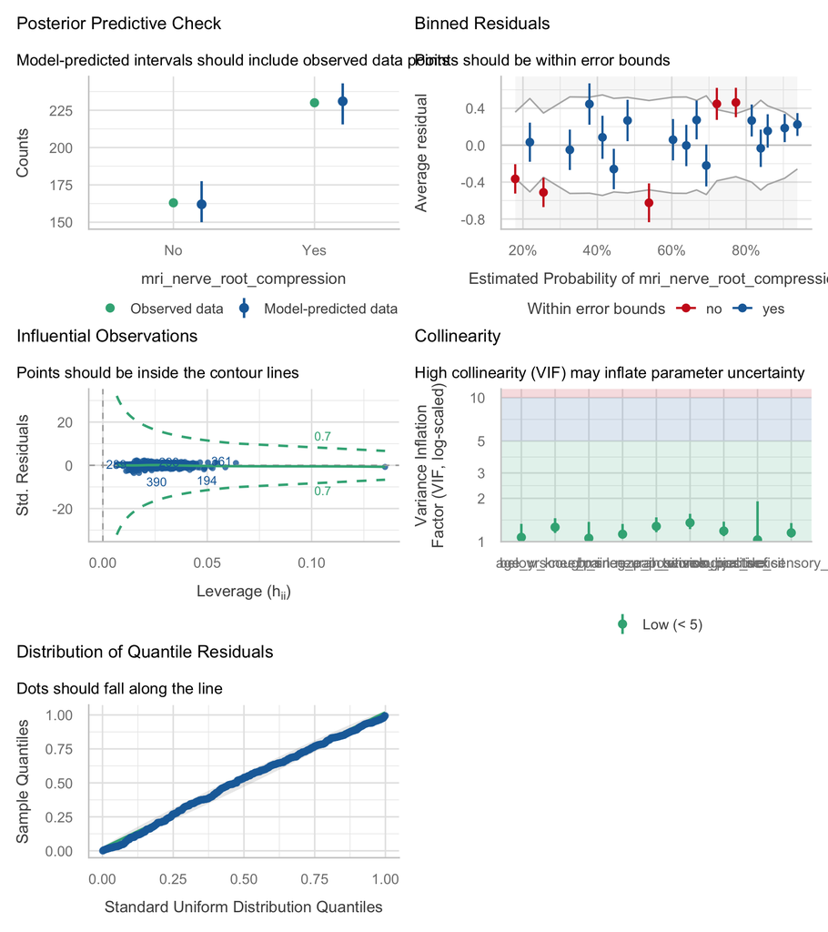

| Term | VIF | VIF_CI_low | VIF_CI_high | SE_factor | Tolerance | Tolerance_CI_low | Tolerance_CI_high |
| --- | --- | --- | --- | --- | --- | --- | --- |
| age_yrs | 1.071991 | 1.015725 | 1.329586 | 1.035370 | 0.9328435 | 0.7521140 | 0.9845185 |
| sex | 1.029661 | 1.000971 | 1.905913 | 1.014722 | 0.9711933 | 0.5246829 | 0.9990298 |
| bmi | 1.056536 | 1.008585 | 1.372300 | 1.027879 | 0.9464891 | 0.7287036 | 0.9914877 |
| leg_pain_worse | 1.278603 | 1.163153 | 1.475746 | 1.130753 | 0.7821037 | 0.6776232 | 0.8597320 |
| cough_sneeze_positive | 1.127886 | 1.049952 | 1.327409 | 1.062020 | 0.8866147 | 0.7533475 | 0.9524245 |
| subjective_sensory_changes | 1.153213 | 1.067729 | 1.346594 | 1.073878 | 0.8671421 | 0.7426145 | 0.9365674 |
| below_knee_pain | 1.260706 | 1.149113 | 1.455812 | 1.122812 | 0.7932063 | 0.6869019 | 0.8702362 |
| neural_tension_positive | 1.353680 | 1.222792 | 1.561463 | 1.163477 | 0.7387272 | 0.6404249 | 0.8178009 |
| neurological_deficit | 1.186516 | 1.092182 | 1.377387 | 1.089273 | 0.8428036 | 0.7260125 | 0.9155984 |

[output not shown]

[output cut: 10 more lines]

**Collinearity in the main model.** All variance inflation factors are low. The largest is neural_tension_positive at 1.35 – nowhere near the conventional threshold of 5. This is worth stating explicitly because the six clinical signs correlate with each other at r = 0.10 to 0.39, which sounds alarming but is far too weak to destabilise a nine-parameter model. The attenuation of `neural_tension_positive` and `below_knee_pain` in the previous section is therefore genuine confounding by the other signs, not a variance-inflation artefact.

**Influential observations.** `check_outliers()` flags 0 observation(s) at the Cook’s-distance threshold, and there is no separation: every fitted probability lies between 0.15 and 0.95, and every coefficient has a finite standard error.

**Events per parameter.** 163 in the rarer class over 10 parameters gives 16.3 events per parameter, above the usual minimum of 10.

What happens if `clinician_sciatica` is added

Sensitivity analysis only - not the reported model

| Term | VIF (main model) | VIF (+ clinician_sciatica) |
| --- | --- | --- |
| clinician_sciatica | NA | 2.21 |
| neural_tension_positive | 1.35 | 1.75 |
| below_knee_pain | 1.26 | 1.44 |
| leg_pain_worse | 1.28 | 1.30 |
| neurological_deficit | 1.19 | 1.28 |
| subjective_sensory_changes | 1.15 | 1.18 |
| cough_sneeze_positive | 1.13 | 1.12 |
| age_yrs | 1.07 | 1.07 |
| bmi | 1.06 | 1.06 |
| sex | 1.03 | 1.03 |

**The `clinician_sciatica` sensitivity model.** Adding the clinician’s diagnosis alongside the signs it is derived from does exactly what the Methods section predicted. The VIF for `neural_tension_positive` rises from 1.35 to 1.75 and `below_knee_pain` from 1.26 to 1.44; the odds ratio for `below_knee_pain` moves from 1.27 to 1 and `neural_tension_positive` from 1.02 to 0.73 – i.e. it flips to the protective side. AIC improves marginally (459.3 to 455.9), which is precisely the trap: a model-selection criterion rewards adding a variable that makes the scientific question unanswerable. The VIFs alone (max 2.21) would not have raised an alarm. The reason to exclude `clinician_sciatica` is that it is a summary of the other predictors, not that a diagnostic test says so.

# Discussion

Among primary-care patients presenting with sciatica, the classical clinical signs are only weakly informative about whether the MRI will show nerve-root compression. Three of the six signs – pain provoked by coughing or sneezing, leg pain reported as worse than back pain, and a neurological deficit – remain independently associated after mutual adjustment, but with odds ratios below 3 and an overall Tjur’s R² of 0.221 and AUC of 0.775. The single strongest predictor of the scan finding is being male, which is not a clinical sign at all. Two signs that clinicians weight heavily – the neural-tension test and subjective sensory changes – carry no independent information about the imaging finding whatsoever.

The result becomes much more interesting when set against the clinician’s own diagnosis. The same six signs explain Tjur’s R² = 0.65 of the GP’s high-confidence sciatica diagnosis but only 0.16 of the MRI finding. The examination is therefore internally coherent – clinicians use the signs consistently and their diagnosis is close to a summary of them – while being only loosely coupled to the anatomy. In practical terms this means a confident clinical diagnosis of sciatica should not be read as a confident prediction of nerve-root compression, and it explains why MRI changes management in a meaningful minority of these patients.

**Limitations.** This is a cross-sectional diagnostic association study; nothing here is causal, and odds ratios are not likelihood ratios, so the model does not directly give the quantities a clinician would use at the bedside. Nerve-root compression on MRI is itself an imperfect reference standard: it is common in asymptomatic people and the file records only its presence, not the level, side or severity, nor whether it corresponds to the symptomatic dermatome – a patient counted as “compression present” may have it on the wrong side. The six signs are recorded as coarse binaries (“at least one neural-tension test positive”, “at least one deficit”), which discards severity and almost certainly attenuates the associations. No inter-observer reliability data are available, so some of the weak signal may be measurement error in the signs rather than a true absence of association. Complete-case analysis dropped 2 rows for missing BMI, which is negligible. The sample is Dutch primary care and the prevalence of compression here (58.5%) will not transfer to secondary care, where selection is stronger.

**Future work.** Linking the side and level of compression to the side and dermatome of the symptoms would test whether the weak signal reflects a genuinely loose sign-anatomy relationship or merely a crude outcome definition.

# Feasibility notes

*Not part of a student report.*